# DM Test - Revision

Friederike Becker

2025-09-05

*Internal discussion document - not polished*

## DM Test results

Show different results for the Diebold-Mariano panel test in R. We compare the results from test statistics $S^3$ and $\tilde{S}^3$ and additionally the effect of prewhitening for S3.

The test statistics $S^3$ and $\tilde{S}^3$ are based on Akgun et al (2024): *Equal predictive ability tests based on panel data with applications to OECD and IMF forecasts*. $S^3$ corresponds to the test statistic we’ve been using so far, while $\tilde{S}^3$ is also valid for small $T$ (uses the t-distribution) but assumes no serial correlation.

## Code for DM - Test

This code is slightly adapted from Fabian’s. It allows for different options in the NeweyWest-function and additionally calculates the test statistic needed for $\tilde{S}^3$.

```r
dm_test <- function(loss1, loss2, lag = NULL, prewhite = TRUE, return_s3tilde = FALSE, df_corr = 1){

    #########################S3 (Fabians Code)###########################
    # make series of loss differences
    # loss1 is for model 1, loss2 is for model 2
    # smaller loss is better
    d <- loss1 - loss2
    # mean loss
    m <- mean(d)
    # variance estimated via Newey-West method
    # regression of d on intercept
    fit <- lm(d~1)
    # robust standard error
    s <- NeweyWest(fit, lag = lag, prewhite = prewhite) |> unname() |> sqrt() |> as.numeric()
    #s_var <- sqrt(sum(fit$residuals^2) / length(loss1))
    # t statistic
    # t > 0 indicates that model 2 is better
    # t < 0 indicates that model 1 is better
    t <- m/s
    # p-value (two-sided)
    p <- 2*pnorm(-abs(t))
    # lag length used by estimator
    k <- bwNeweyWest(fit, lag = lag, prewhite = prewhite)


    #########################S3-Tilde###########################
    #calculate variance estimate and t-stat for s3-tilde:
    std_var <- sum(fit$residuals^2) / (length(loss1) - df_corr)
    s_var <- sqrt(std_var / (length(loss1)))
    t_s3tilde <- m /s_var


    #########################Output###########################
    if(!return_s3tilde){
      list(t_stat = t, p_val = p, bandwidth = k, resids = fit$residuals)
    } else {
      list(t_stat = t, p_val = p, bandwidth = k, t_s3tilde = t_s3tilde, resids = fit$residuals)
    }
  }
```

## Automatic lag choice and prewhitening

This is the default option implemented in the NeweyWest-function, and the setting we have so far been using. It is obtained by running

```r
NeweyWest(fit)
```

We thereby get the following results

|  | model1 | model2 | horizon | target | tstat | p_val | bandwidth |
| --- | --- | --- | --- | --- | --- | --- | --- |
| 1 | IMF | ar | 0 | ngdp_rpch | -0.8177938819249404 | 0.4134748921143186 | 1.256281777961328 |
| 2 | IMF | bvar_const | 0 | ngdp_rpch | -0.4418617236500774 | 0.6585892700712135 | 1.092076235911309 |
| 3 | IMF | bvar_const-direct | 0 | ngdp_rpch | -0.9822319620239581 | 0.325985584799604 | 1.949383887592105 |
| 4 | IMF | ar | 0 | pcpi_pch | -1.3313143658922 | 0.183085593193161 | 0.2722715615959783 |
| 5 | IMF | bvar_const | 0 | pcpi_pch | -1.497163579275875 | 0.1343506995618587 | 0.1878251350134242 |
| 6 | IMF | bvar_const-direct | 0 | pcpi_pch | -1.417630770346483 | 0.1562985916797517 | 0.246073395127048 |
| 7 | IMF | ar | 0.5 | ngdp_rpch | -1.541855978021105 | 0.1231085955392995 | 0.3739954242317357 |
| 8 | IMF | bvar_const | 0.5 | ngdp_rpch | -1.286973515873693 | 0.1981035193178858 | 0.3885643413181911 |
| 9 | IMF | bvar_const-direct | 0.5 | ngdp_rpch | -1.216188385953415 | 0.2239131669120734 | 0.3818390045547828 |
| 10 | IMF | ar | 0.5 | pcpi_pch | -0.0925163770339579 | 0.926287780032192 | 0.1090576655960913 |

[output cut: 14 more lines]

With 4 significant results, as before (since it’s the same code that we’ve run so far).

|  | model1 | model2 | horizon | target | tstat | p_val | bandwidth |
| --- | --- | --- | --- | --- | --- | --- | --- |
| 1 | IMF | ar | 1 | ngdp_rpch | -2.697018436299103 | 0.006996339673819938 | 0.7554184709553026 |
| 2 | IMF | bvar_const | 1 | ngdp_rpch | -2.245673640561277 | 0.02472491976695175 | 1.160748959905974 |
| 3 | IMF | bvar_const-direct | 1 | ngdp_rpch | -2.197220914213176 | 0.02800467263529122 | 1.047198490201219 |
| 4 | IMF | ar | 1.5 | ngdp_rpch | -2.762295773262936 | 0.005739645697117934 | 0.6939854199113555 |

## Automactic lag choice and no prewhitening

Here, we calculate the variance based on the raw residuals by running

```r
NeweyWest(fit, prewhite = FALSE)
```

```
## Warning in meatHAC(x, order.by = order.by, prewhite = prewhite, weights =
## weights, : more weights than observations, only first n used
## Warning in meatHAC(x, order.by = order.by, prewhite = prewhite, weights =
## weights, : more weights than observations, only first n used
## Warning in meatHAC(x, order.by = order.by, prewhite = prewhite, weights =
## weights, : more weights than observations, only first n used
## Warning in meatHAC(x, order.by = order.by, prewhite = prewhite, weights =
## weights, : more weights than observations, only first n used
## Warning in meatHAC(x, order.by = order.by, prewhite = prewhite, weights =
## weights, : more weights than observations, only first n used
## Warning in meatHAC(x, order.by = order.by, prewhite = prewhite, weights =
## weights, : more weights than observations, only first n used
```

|  | model1 | model2 | horizon | target | tstat | p_val | bandwidth |
| --- | --- | --- | --- | --- | --- | --- | --- |
| 1 | IMF | ar | 0 | ngdp_rpch | -3.189711228643783 | 0.001424150207706564 | 67.95240446439298 |
| 2 | IMF | bvar_const | 0 | ngdp_rpch | -0.8052608969732072 | 0.4206691416104665 | 14.48833767617667 |
| 3 | IMF | bvar_const-direct | 0 | ngdp_rpch | -1.705511092795746 | 0.08809914521516142 | 12.8225271236115 |
| 4 | IMF | ar | 0 | pcpi_pch | -1.258509546874143 | 0.2082075367514077 | 1.501027580754178 |
| 5 | IMF | bvar_const | 0 | pcpi_pch | -1.289376903108842 | 0.1972670870969392 | 0.3908698527715777 |
| 6 | IMF | bvar_const-direct | 0 | pcpi_pch | -1.271976182126931 | 0.2033815819675786 | 0.4619730468876557 |
| 7 | IMF | ar | 0.5 | ngdp_rpch | -2.269639414466607 | 0.02322947013697417 | 5.085993544285361 |
| 8 | IMF | bvar_const | 0.5 | ngdp_rpch | -1.964631784500731 | 0.04945687044608366 | 5.622111765849016 |
| 9 | IMF | bvar_const-direct | 0.5 | ngdp_rpch | -2.0491603386143 | 0.0404464389099002 | 6.284184086693234 |
| 10 | IMF | ar | 0.5 | pcpi_pch | -0.09499901285647998 | 0.9243156110021202 | 0.7394843322319669 |

[output cut: 14 more lines]

With 10 significant results. Note the warnings above, which stem from the bandwidth parameters, which are in some cases very large.

|  | model1 | model2 | horizon | target | tstat | p_val | bandwidth |
| --- | --- | --- | --- | --- | --- | --- | --- |
| 1 | IMF | ar | 0 | ngdp_rpch | -3.189711228643783 | 0.001424150207706564 | 67.95240446439298 |
| 2 | IMF | ar | 0.5 | ngdp_rpch | -2.269639414466607 | 0.02322947013697417 | 5.085993544285361 |
| 3 | IMF | bvar_const | 0.5 | ngdp_rpch | -1.964631784500731 | 0.04945687044608366 | 5.622111765849016 |
| 4 | IMF | bvar_const-direct | 0.5 | ngdp_rpch | -2.0491603386143 | 0.0404464389099002 | 6.284184086693234 |
| 5 | IMF | ar | 1 | ngdp_rpch | -8.340676537732516 | 7.38666956667614e-17 | 35.45085221017183 |
| 6 | IMF | bvar_const | 1 | ngdp_rpch | -4.856955293448808 | 1.19204494519181e-06 | 14.78650459544213 |
| 7 | IMF | bvar_const-direct | 1 | ngdp_rpch | -5.821126868824035 | 5.845217724400744e-09 | 21.8771049560243 |
| 8 | IMF | ar | 1.5 | ngdp_rpch | -3.743401171050059 | 0.0001815460271282349 | 3.789742505036671 |
| 9 | IMF | bvar_const | 1.5 | ngdp_rpch | -1.981937227694839 | 0.04748626668555509 | 3.016673914082724 |
| 10 | IMF | bvar_const-direct | 1.5 | ngdp_rpch | -1.984555110453588 | 0.0471939908601085 | 3.319317413905416 |

## S3-Tilde

Compare to results obtained by calculating the variance only using lag = 0, based on the raw residuals, with significance determined by the t-distribution:

|  | model1 | model2 | horizon | target | tstat | t_s3tilde |
| --- | --- | --- | --- | --- | --- | --- |
| 1 | IMF | ar | 0 | ngdp_rpch | -0.8177938819249404 | -0.4584090331848347 |
| 2 | IMF | bvar_const | 0 | ngdp_rpch | -0.4418617236500774 | -0.2532117646663836 |
| 3 | IMF | bvar_const-direct | 0 | ngdp_rpch | -0.9822319620239581 | -0.4744489273438231 |
| 4 | IMF | ar | 0 | pcpi_pch | -1.3313143658922 | -1.140402232985314 |
| 5 | IMF | bvar_const | 0 | pcpi_pch | -1.497163579275875 | -1.229372640551619 |
| 6 | IMF | bvar_const-direct | 0 | pcpi_pch | -1.417630770346483 | -1.212781704069467 |
| 7 | IMF | ar | 0.5 | ngdp_rpch | -1.541855978021105 | -1.270545661490248 |
| 8 | IMF | bvar_const | 0.5 | ngdp_rpch | -1.286973515873693 | -1.071002650252111 |
| 9 | IMF | bvar_const-direct | 0.5 | ngdp_rpch | -1.216188385953415 | -1.018558542884102 |
| 10 | IMF | ar | 0.5 | pcpi_pch | -0.0925163770339579 | -0.09057800477391471 |

[output cut: 14 more lines]

Based on the above, we get 1 significant results:

|  | model1 | model2 | horizon | target | tstat | p_val | bandwidth | t_s3tilde |
| --- | --- | --- | --- | --- | --- | --- | --- | --- |
| 1 | IMF | ar | 1.5 | ngdp_rpch | -2.762295773262936 | 0.005739645697117934 | 0.6939854199113555 | -3.182547114714401 |

## Sanity Check: Lag choice = 0 and no prewhitening

Side note (more of a sanity check). If we don’t do prewhitening and set lag = 0 for $S^3$ *and* we don’t do the degrees of freedom correction for $\tilde{S}^3$ (i.e. divide by T and not by T-1), the two test statistics do coincide:

```r
NeweyWest(fit, lag = 0, prewhite = FALSE)
```

|  | model1 | model2 | horizon | target | tstat | t_s3tilde |
| --- | --- | --- | --- | --- | --- | --- |
| 1 | IMF | ar | 0 | ngdp_rpch | -0.4807834500853793 | -0.4807834500853793 |
| 2 | IMF | bvar_const | 0 | ngdp_rpch | -0.2655707392428813 | -0.2655707392428813 |
| 3 | IMF | bvar_const-direct | 0 | ngdp_rpch | -0.497606233003039 | -0.4976062330030391 |
| 4 | IMF | ar | 0 | pcpi_pch | -1.196063952427996 | -1.196063952427996 |
| 5 | IMF | bvar_const | 0 | pcpi_pch | -1.289376903108842 | -1.289376903108842 |
| 6 | IMF | bvar_const-direct | 0 | pcpi_pch | -1.271976182126931 | -1.271976182126931 |
| 7 | IMF | ar | 0.5 | ngdp_rpch | -1.33255953177517 | -1.33255953177517 |
| 8 | IMF | bvar_const | 0.5 | ngdp_rpch | -1.123277055998097 | -1.123277055998097 |
| 9 | IMF | bvar_const-direct | 0.5 | ngdp_rpch | -1.068273212156143 | -1.068273212156143 |
| 10 | IMF | ar | 0.5 | pcpi_pch | -0.09499901285647998 | -0.09499901285647998 |

[output cut: 14 more lines]

## Additional Info: ACF curves

Here, we show the autocorrelation of the demeaned loss differentials. The header displays the respective competing model and the forecast horizon.

### GDP

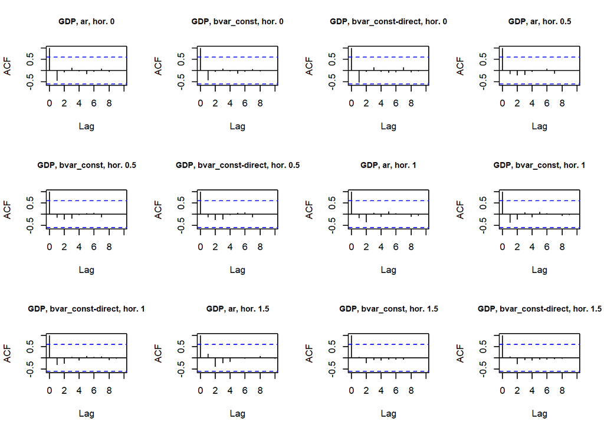

### Inflation

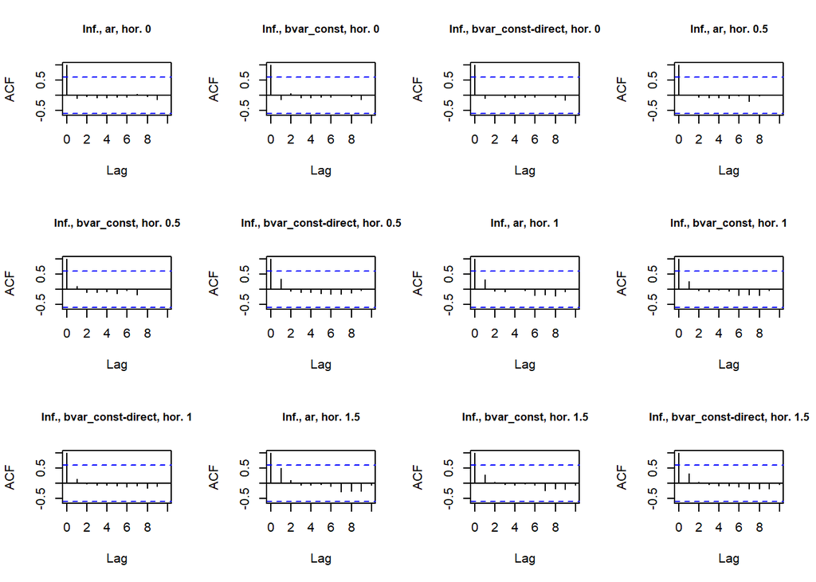